[Ghezae Fisseha](https://gafstar.github.io/)

# Binary Classification Using XGBoost

May 27, 2021 in [Machine Learning](https://gafstar.github.io/categories/machine-learning)

### 1. Introduction

The purpose of this post it to understand how to apply XGBoost to a binary classification problem. In this post we are going to see how to apply XGBoost classifier algorithm to an adult data set downloaded from [UCI Machine Learning Repository](https://archive.ics.uci.edu/ml/datasets/adult).

XGBoost is an optimized gradient boosting open source library knows for its flexibility and portability. It is also a popular algorithm for machine learning competitions for structured or tabular dataset. In [Kaggle competitions,](https://www.kaggle.com/) it is the number one choice for tabular dataset.

```python
# Importing necessary libraries
import pandas as pd
import numpy as np
```

First download the dataset from the UCI machine learning repository.

```python
path = '/content/drive/MyDrive/Colab Notebooks/adult.csv'
df = pd.read_csv(path)

# saving a copy of the data for later experimentation
df2 = df.copy()
```

Take a peek into the first 5 rows of the dataset to see we have the right type of data.

```python
df.head()
```

|  | age | workclass | fnlwgt | education | educational-num | marital-status | occupation | relationship | race | gender | capital-gain | capital-loss | hours-per-week | native-country | income |
| --- | --- | --- | --- | --- | --- | --- | --- | --- | --- | --- | --- | --- | --- | --- | --- |
| 0 | 25 | Private | 226802 | 11th | 7 | Never-married | Machine-op-inspct | Own-child | Black | Male | 0 | 0 | 40 | United-States | <=50K |
| 1 | 38 | Private | 89814 | HS-grad | 9 | Married-civ-spouse | Farming-fishing | Husband | White | Male | 0 | 0 | 50 | United-States | <=50K |
| 2 | 28 | Local-gov | 336951 | Assoc-acdm | 12 | Married-civ-spouse | Protective-serv | Husband | White | Male | 0 | 0 | 40 | United-States | >50K |
| 3 | 44 | Private | 160323 | Some-college | 10 | Married-civ-spouse | Machine-op-inspct | Husband | Black | Male | 7688 | 0 | 40 | United-States | >50K |
| 4 | 18 | ? | 103497 | Some-college | 10 | Never-married | ? | Own-child | White | Female | 0 | 0 | 30 | United-States | <=50K |

Similarly, we use the `.info()` method to print out a concise summary of the dataframe. In the output, we can check total non-null rows, total columns, data type and the size of memory usage.

```python
df.info()
```

```
<class 'pandas.core.frame.DataFrame'>
RangeIndex: 48842 entries, 0 to 48841
Data columns (total 15 columns):
 #   Column           Non-Null Count  Dtype
---  ------           --------------  -----
 0   age              48842 non-null  int64
 1   workclass        48842 non-null  object
 2   fnlwgt           48842 non-null  int64
 3   education        48842 non-null  object
 4   educational-num  48842 non-null  int64
 5   marital-status   48842 non-null  object
 6   occupation       48842 non-null  object
 7   relationship     48842 non-null  object
 8   race             48842 non-null  object
 9   gender           48842 non-null  object
 10  capital-gain     48842 non-null  int64
 11  capital-loss     48842 non-null  int64
 12  hours-per-week   48842 non-null  int64
 13  native-country   48842 non-null  object
 14  income           48842 non-null  object
dtypes: int64(6), object(9)
memory usage: 5.6+ MB
```

As we can see, we only have numerical (represented with `int64` data type) and categorical (represented with `object` data types) features. At a glance, it appears that there are no missing values.

### 2. Data Preparation

We are going to prepare the data for modeling. This is an important step before we create our XGBoost model. XGBoost models don't handle categorical features, so we will use `one-hot-encoding` to use to convert the string values to encoded integer values. We are going to address how to handle missing values. Also we will carry out some feature transformation for a few columns with many categories. This are important steps that will give our model better predictive power.

#### 2.1 Data Cleaning - Missing Values

```python
print (f'Rows and columns before nan values removal {df.shape}')
df['native-country'] = df['native-country'].replace('?',np.nan)
df['workclass'] = df['workclass'].replace('?',np.nan)
df['occupation'] = df['occupation'].replace('?',np.nan)

perc = df.isnull().sum().sum() * 100/df.shape[0]
df.dropna(how='any',inplace=True)
print (f'Rows and columns before nan values removal {df.shape}')

print(f'Percent of missing values is: {round(perc)}%')
```

```
Rows and columns before nan values removal (48842, 15)
Rows and columns before nan values removal (45222, 15)
Percent of missing values is: 13%
```

About 13% of our data is missing value, therefore, we have dropped all the missing rows the rows that contain missing value. This is not the wise strategy, because, we will be discarding useful information. The best option would be to impute the missing values through advanced techiniques. For example, we can say that the missing value for each of the columns is a rare value and could have labeled it as `rare`. Or we could have used other advanced imputation methods to fill out the missing values. In this post, we will just proceed by discarding the missing values. Again, noot a wise strategy, but if interested you can checkout this post on how to handle missing values.

#### 2.2 Feature Transformation

Next step, we are going to transform a few of the features. In this post we will only transform three categorical columns, namely, `native-country`, `marital-status` and `workclass`. We can also make do feature transformation for the numerical variables, but in this post we are applying only to three columns.

```python
###  Categorizing countries to US and Non-US
df.loc[df['native-country'] != 'United-States', 'native-country'] = 'Non-US'
df.loc[df['native-country'] == 'United-States', 'native-country'] = 'US'

# Converting native country to integer mapping
df['native-country'] = df['native-country'].map({'US':1,'Non-US':0}).astype(int)

# Categorize marital-status into couple and single
df['marital-status'] = df['marital-status'].replace(['Divorced','Married-spouse-absent', \
'Never-married','Separated','Widowed'],'Single')

df['marital-status'] = df['marital-status'].replace(['Married-AF-spouse','Married-civ-spouse'],\
'Couple')

## Categorizing workclass
def f(x):
    if x['workclass'] == 'Federal-gov' or x['workclass']== 'Local-gov' \
          or x['workclass']=='State-gov':
        return 'govt'
    elif x['workclass'] == 'Private':
        return 'private'
    elif x['workclass'] == 'Self-emp-inc' or x['workclass'] == 'Self-emp-not-inc':
        return 'self_employed'
    else:
        return 'without_pay'

df['workclass']=df.apply(f, axis=1)
# df.drop(['workclass'], axis = 1)
df.head()
```

|  | age | workclass | fnlwgt | education | educational-num | marital-status | occupation | relationship | race | gender | capital-gain | capital-loss | hours-per-week | native-country | income |
| --- | --- | --- | --- | --- | --- | --- | --- | --- | --- | --- | --- | --- | --- | --- | --- |
| 0 | 25 | private | 226802 | 11th | 7 | Single | Machine-op-inspct | Own-child | Black | Male | 0 | 0 | 40 | 1 | <=50K |
| 1 | 38 | private | 89814 | HS-grad | 9 | Couple | Farming-fishing | Husband | White | Male | 0 | 0 | 50 | 1 | <=50K |
| 2 | 28 | govt | 336951 | Assoc-acdm | 12 | Couple | Protective-serv | Husband | White | Male | 0 | 0 | 40 | 1 | >50K |
| 3 | 44 | private | 160323 | Some-college | 10 | Couple | Machine-op-inspct | Husband | Black | Male | 7688 | 0 | 40 | 1 | >50K |
| 5 | 34 | private | 198693 | 10th | 6 | Single | Other-service | Not-in-family | White | Male | 0 | 0 | 30 | 1 | <=50K |

Similarly, we encode our target variable `income` to 0 and 1 by mapping it. We map the salary of the people who earn `>50K` as 1 and 0 otherwise.

```python
#label encode the target variable to have the classes 0 and 1
income_map={'<=50K':0,'>50K':1}
df['income']=df['income'].map(income_map).astype(int)
```

#### 2.3 Split the data into target variable and predictor variables

We split the dataset into target variable `y` and predictor variables dataframe represented by `X`.

```python
# We remove the target class and create a new object 'X'
y = df['income']
X = df.drop(['income'], axis = 1)
```

#### 2.4 Encoding Categorical Features

Let's select the categorical and numerical features into `cat_ix` and `num_ix` list. This list will help us separate the categorical features from the numerical features of the dataframe. In this example, we are going to use an extreme gradient boosted tree `xgboost` model, a powerful variation of tree-based models. Normally, when we are working with tree-based models like `decision tree`, `random forest` we don't normalize the numerical features. However, if we are working with linear models likes `logistic regression` we should normalize our data.

```python
# select categorical and numerical features
cat_ix = X.select_dtypes(include=['object', 'bool']).columns
num_ix = X.select_dtypes(include=['int64', 'float64']).columns
```

Next, we are going to encode the categorical features, since `xgboost` doesn't handle categorical features. In this example, we are going to use one-hot encoding. We are going to add the encoded features to our dataframe `X`, which contains the predictor features. Then we are going to remove the unencoded categorical features from the dataframe.

```python
categories = cat_ix
print("Starting DF shape: %d, %d" % X.shape)


for col in categories:
    s = df[col].unique()

    # Create a One Hot Dataframe with 1 row for each unique value
    one_hot_df = pd.get_dummies(s, prefix='%s_' % col)
    one_hot_df[col] = s

    print("Adding One Hot values for %s (the column has %d unique values)" % (col, len(s)))
    pre_len = len(X)

    # Merge the one hot columns
    X = X.merge(one_hot_df, on=[col], how="left")
    assert len(X) == pre_len
    print(X.shape)
```

```
Starting DF shape: 45222, 14
Adding One Hot values for workclass (the column has 4 unique values)
(45222, 18)
Adding One Hot values for education (the column has 16 unique values)
(45222, 34)
Adding One Hot values for marital-status (the column has 2 unique values)
(45222, 36)
Adding One Hot values for occupation (the column has 14 unique values)
(45222, 50)
Adding One Hot values for relationship (the column has 6 unique values)
(45222, 56)
Adding One Hot values for race (the column has 5 unique values)
(45222, 61)
Adding One Hot values for gender (the column has 2 unique values)
(45222, 63)
```

```python
# Unique values in education feature
X.education.unique()
```

```
array(['11th', 'HS-grad', 'Assoc-acdm', 'Some-college', '10th',
       'Prof-school', '7th-8th', 'Bachelors', 'Masters', '5th-6th',
       'Assoc-voc', '9th', 'Doctorate', '12th', '1st-4th', 'Preschool'],
      dtype=object)
```

```python
len(df2['native-country'].unique())
```

```
42
```

After encoding our categorical variables with one-hot-encoding, it is time to remove them from the predictor variables. We only keep the one-hot-encoded version of them.

```python
# dropping the original categorical variables
X = X.drop(cat_ix.to_list(), axis = 1)
```

#### 2.5 Peeking at Target Class

Let's check the percentage of people who earn a salary above or below 50K.

```python
from collections import Counter
df = df.dropna()
# summarize the shape of the dataset
print(df.shape)
# summarize the class distribution
target = df['income'].values
counter = Counter(target)
for k,v in counter.items():
    per = v / len(target) * 100
    print('Class=%s, Percentage=%.3f%%' % (k, per))
```

```
(45222, 15)
Class=0, Percentage=75.216%
Class=1, Percentage=24.784%
```

### 3. Build The Model

Now let's split the original data into training and testing data subsets. We are going to use the `train_test_split` function from `sklearn` library. We will hold out 20% of the data for testing purpose.

```python
# splitting the data into subsets: 80% training and 20% testing
from sklearn.model_selection import train_test_split
X_train, X_test, y_train, y_test = train_test_split(X,
                                                    y,
                                                    test_size = 0.2,
                                                    random_state = 42)

X_train.head(3)
```

[output not shown]

It is time to fit a model on the training dataset and evaluate it with the testing dataset. But the big question is how do we evaluate that our model is doing good? What metric do we use that would give us meaningful result. We should consider choosing the right metric before jumping to fit a model. Common binaray classification metrics include `accuracy`, `f1-score`, `ROC AUC` and `PR AUC`. We have to analyze the pros and cons of choosing any of them. In this post we will use `ROC AUC` since our data is skewed and we equally care about both of the target classes.

```python
# Loading the auc function
from sklearn.metrics import roc_auc_score
```

#### 3.1 XGBoost Parameteres

We are going to see a few parameters that we are going to use to build the model.

`max_depth`[default=6]: refers to the maximum depth of a tree. The higher the value the more complex your model will be.

`eta`[default=0.3]: learning rate

`silent`[bool]: refers whether print messages during construction.

`eval_metric`: refers to evaluation metric. For binary classification in this example we are choosing `ROC AUC`.

`subsample`[default = 1]: refers to subsample ratio of the training instances. Setting it to 0.5 means that XGBoost would randomly sample half of the training data prior to growing trees and this will prevent overfitting.

`colsample_bytree`: refers to the subsample ratio of columns when constructing each tree. Subsampling occurs once for every node constructed.

`objective`: refers to learning objective. For binary classification, it uses logistic regression to output probability.

`seed`: refers to random number generator for reproducibility of results

There are many parameters we can add to these, however, those parameters described above are for the sake of example. If you want to check out other parameters, please go to [XGBoost official documentation](https://xgboost.readthedocs.io/en/latest/parameter.html).

`dtrain`[DMatrix]: data to be trained

`num_boost_round`[int]: number of boosting iterations

`verbose_eval`[bool or int]: If True, it prints out the evaluation metric on the validation set at each boosting stage. If `verbose_eval = 50`, it will print an evaluation metric every 50 boosting stages instead of every boosting stage.

`early_stopping_rounds`[int]: Activates early stopping. Validation metric needs to improve at least once in every early_stopping_rounds round(s) to continue training.

`evals`[string]: List of validation sets for which metrics will evaluated during training. Validation metrics will help us track the performance of the model.

`maximize`[bool]: Referes whether to maximize the eval or not.

#### 3.2 Modeling

In this post we are going to use the third party package for XGBoost assuming that we have already installed `xgboost` in our machine. If you have trouble installing `xgboost` please refer to the [installation guide](https://xgboost.readthedocs.io/en/release_0.81/build.html) which will show you how to install xgboost step by step. After we complete installation, we import the `xgboost` library and create a dictionary for the parameters.

XGBoost uses an internal data structure called `DMatrix`, which is optimized both for memory efficiency and training speed. We will create two `DMatrix`s for training and testing datasets.

```python
# If you haven't installed xgboost, you can install it by typing
# pip install xgboost
# in your terminal
# Loading the xgboost library
import xgboost as xgb

# Initializing the params
xgb_params = {
    'max_depth':3,
    'eta':0.01,
    'silent':0,
    'eval_metric': 'auc',
    'subsample':0.8,
    'colsample_bytree':0.8,
    'objective':'binary:logistic',
    'seed': 42
}
# Convert the predictor and target variables to Dmatrix data structure
dtrain = xgb.DMatrix(X_train, y_train, feature_names=X_train.columns.values)
dtest =   xgb.DMatrix(X_test, y_test, feature_names=X_test.columns.values)

# create a list of evaluation criteria for training and test data
evals = [(dtrain, 'train'), (dtest, 'eval')]
xgb_model = xgb.train(params = xgb_params,
                      dtrain = dtrain,
                      num_boost_round = 100,
                      verbose_eval = 25,
                      early_stopping_rounds = 25,
                      evals = evals,
                      maximize = True
                    )
```

[output not shown]

#### 3.3 Model Output Explanation

We can choose the first tree and inspect how it is arriving at the decision.

```python
# Outputing human readable model output
print(xgb_model.get_dump()[0])
```

```
0:[marital-status__Couple<1] yes=1,no=2,missing=1
	1:[capital-gain<7056] yes=3,no=4,missing=3
		3:[educational-num<14] yes=7,no=8,missing=7
			7:leaf=-0.0184805878
			8:leaf=-0.009390519
		4:[capital-gain<8296] yes=9,no=10,missing=9
			9:leaf=0.00363636366
			10:leaf=0.0191335734
	2:[educational-num<13] yes=5,no=6,missing=5
		5:[capital-gain<5096] yes=11,no=12,missing=11
			11:leaf=-0.00765013928
			12:leaf=0.0189979114
		6:[capital-gain<5096] yes=13,no=14,missing=13
			13:leaf=0.00708369538
			14:leaf=0.0198089164
```

```python
# score from first tree leaf 10
score = 1/(1 + np.exp(-1 * 0.0184805878))
print(f'The probability of class 1 from the first tree at leaf 7 is {round(score,3)}')
```

[output not shown]

Let's say the sum of the scores of first 10 trees at leaf 7 is 0.25. Applying logistic function will yield:

```python
# score from first tree leaf 10
score = 1/(1 + np.exp(-1 * 0.25))
print(f'The score of the first 10 trees at leaf 7 is {round(score,3)}')
```

```
The score of the first 10 trees at leaf 7 is 0.562
```

#### 3.4 Model Output Visualization

The `plot_tree` function takes a few parameters. The `num_trees` parameter specifies the ordinal number of target tree. For instance, we have `num_trees = 0` which will print out the first tree.

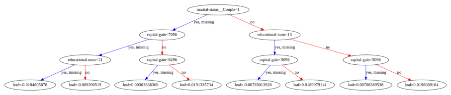

```python
fig, ax = plt.subplots(figsize = (16, 38))
xgb.plot_tree(xgb_model, ax = ax, num_trees= 0)
plt.show()
```

### 4. Feature Importance

#### 4.1 Feature Importance Visualization

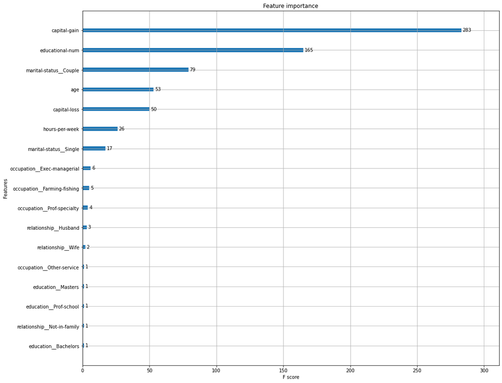

```python
# Plotting feature importance
import matplotlib.pyplot as plt
fig, ax = plt.subplots(figsize = (16,14))
xgb.plot_importance(xgb_model, ax = ax)
plt.show()
```

In the above feature importance plot, `F Score` is a metric that simply sums up how many time each feature is split on. You can think of it as `frequency score`, because it measures the frequency of a given feature is being splitted. This shouldn't be confused with `f1 score`, a commonly used accuracy score in machine learning for imbalanced dataset.

`Capital-gain`, `education-num`, `marital-status__Couple`, `age`, `capital-loss`, `hours-per-week` and `marital-status__Single` seem to have high importance in our dataset.

### 6. Further Reading:

- [XGBoost Documentation](https://xgboost.readthedocs.io/en/release_0.81/index.html)
- [Data Preparation for Gradient Boosting with XGBoost in Python](https://machinelearningmastery.com/data-preparation-gradient-boosting-xgboost-python/)
- [Understand your dataset with Xgboost](https://cran.r-project.org/web/packages/xgboost/vignettes/discoverYourData.html)

TAGGED IN  
[Python](https://gafstar.github.io/tags/python/)

- [Share on Facebook](https://www.facebook.com/sharer/sharer.php?u=https%3A%2F%2Fgafstar.github.io%2F2021%2F05%2F27%2Fbinary-classification-using-xgboost%2F)
- [Share on Twitter](https://twitter.com/intent/tweet?text=https%3A%2F%2Fgafstar.github.io%2F2021%2F05%2F27%2Fbinary-classification-using-xgboost%2F)
- [Share on Google+](https://plus.google.com/share?url=https%3A%2F%2Fgafstar.github.io%2F2021%2F05%2F27%2Fbinary-classification-using-xgboost%2F)

[figure not shown]

#### Ghezae Fisseha

Data Science | Analytics | Business Intelligence

Data Scientist/Analytics

Redwood City, CA